# 複数地点のデータを処理する

Y.Hatanaka

2018/11/8

## 複数地点のデータをどうするか

地点名で分けて，リストにしてみる。

地点名 => その地点のデータフレーム  
別の地点 => その地点のデータフレーム

てな感じ。

まず，酒田と飛島からゴチャゴチャと適当にデータ取って…

```r
# データ読み込み ファイル名指定
f <-
  read.table(
    'data-m.csv',
    sep = ",",
    skip = 1,
    header = F,
    fileEncoding = "Shift_JIS",
    stringsAsFactors = F
  )

head(f)
```

```
##       V1           V2           V3           V4                   V5
## 1                酒田         酒田         酒田                 酒田
## 2   年月 平均気温(℃) 平均気温(℃) 平均気温(℃) 日最高気温の平均(℃)
## 3                         品質情報     均質番号
## 4 2009/1          2.7            8            1                  5.4
## 5 2009/2          2.7            8            1                  6.1
## 6 2009/3          4.9            8            1                  9.0
##                     V6                   V7                   V8
## 1                 酒田                 酒田                 酒田
## 2 日最高気温の平均(℃) 日最高気温の平均(℃) 日最低気温の平均(℃)
## 3             品質情報             均質番号
## 4                    8                    1                 -0.1
## 5                    8                    1                 -0.3
## 6                    8                    1                  1.2
##                     V9                  V10              V11
```

[output cut: 34 more lines]

この後に，まず地点名をピックアップ。

```r
# # 地点ごとに分割
# 場所のリスト
placeList <- unique(f[1,])
placeList
```

```
##   V1   V2   V3   V4   V5   V6   V7   V8   V9  V10  V11  V12  V13  V14  V15
## 1    酒田 酒田 酒田 酒田 酒田 酒田 酒田 酒田 酒田 酒田 酒田 酒田 酒田 飛島
##    V16  V17  V18  V19  V20  V21  V22  V23  V24  V25  V26
## 1 飛島 飛島 飛島 飛島 飛島 飛島 飛島 飛島 飛島 飛島 飛島
```

?

```r
str(f[1,])
```

```
## 'data.frame':    1 obs. of  26 variables:
##  $ V1 : chr ""
##  $ V2 : chr "酒田"
##  $ V3 : chr "酒田"
##  $ V4 : chr "酒田"
##  $ V5 : chr "酒田"
##  $ V6 : chr "酒田"
##  $ V7 : chr "酒田"
##  $ V8 : chr "酒田"
##  $ V9 : chr "酒田"
##  $ V10: chr "酒田"
##  $ V11: chr "酒田"
##  $ V12: chr "酒田"
##  $ V13: chr "酒田"
##  $ V14: chr "酒田"
##  $ V15: chr "飛島"
##  $ V16: chr "飛島"
##  $ V17: chr "飛島"
##  $ V18: chr "飛島"
##  $ V19: chr "飛島"
##  $ V20: chr "飛島"
##  $ V21: chr "飛島"
##  $ V22: chr "飛島"
##  $ V23: chr "飛島"
##  $ V24: chr "飛島"
##  $ V25: chr "飛島"
##  $ V26: chr "飛島"
```

helpじゃデータフレームもOKってなってるけどなぁ… 列単位じゃなきゃダメか？

んじゃmatrixにして…

```r
placeList <- unique(as.matrix(f[1,]))
placeList
```

```
##   V1 V2     V3     V4     V5     V6     V7     V8     V9     V10    V11
## 1 "" "酒田" "酒田" "酒田" "酒田" "酒田" "酒田" "酒田" "酒田" "酒田" "酒田"
##   V12    V13    V14    V15    V16    V17    V18    V19    V20    V21
## 1 "酒田" "酒田" "酒田" "飛島" "飛島" "飛島" "飛島" "飛島" "飛島" "飛島"
##   V22    V23    V24    V25    V26
## 1 "飛島" "飛島" "飛島" "飛島" "飛島"
```

…matrixにしても列単位でのuniqueか？

ほんじゃ…

```r
placeList <- unique(as.vector(as.matrix(f[1,])))
placeList
```

```
## [1] ""     "酒田" "飛島"
```

よし。…じゃないな，そっか，“”があるか。

どうせだから，最初から“”はNULLに。

```r
f <-
  read.table(
    'data-m.csv',
    sep = ",",
    skip = 1,
    header = F,
    fileEncoding = "Shift_JIS",
    stringsAsFactors = F,
# 空白を削除する
        na.strings=c("", "NULL")
)
placeList <- unique(as.vector(as.matrix(f[1,])))
placeList
```

```
## [1] NA     "酒田" "飛島"
```

NAとして出るか。ならNAは無視して…

```r
placeWithNull <- unique(as.vector(as.matrix(f[1,])[1,]))
placeList <- placeWithNull[!is.na(placeWithNull)]
placeList
```

```
## [1] "酒田" "飛島"
```

これで地点名は取得できた，と。

次は，この地点ごとにデータフレームをまとめて，リストに収納。

まずデータフレームの「ガワ」作って，地点毎にまとめて，地点名を名前にしてリストに入れる，と。

```r
#
dfList <- list()
for(i in placeList){
  thisPlaceDf <- f[,which(f[1,] == i)]
  dfList[[i]] <- thisPlaceDf
}
str(dfList)
```

```
## List of 2
##  $ 酒田:'data.frame':  122 obs. of  13 variables:
##   ..$ V2 : chr [1:122] "酒田" "平均気温(℃)" NA "2.7" ...
##   ..$ V3 : chr [1:122] "酒田" "平均気温(℃)" "品質情報" "8" ...
##   ..$ V4 : chr [1:122] "酒田" "平均気温(℃)" "均質番号" "1" ...
##   ..$ V5 : chr [1:122] "酒田" "日最高気温の平均(℃)" NA "5.4" ...
##   ..$ V6 : chr [1:122] "酒田" "日最高気温の平均(℃)" "品質情報" "8" ...
##   ..$ V7 : chr [1:122] "酒田" "日最高気温の平均(℃)" "均質番号" "1" ...
##   ..$ V8 : chr [1:122] "酒田" "日最低気温の平均(℃)" NA "-0.1" ...
##   ..$ V9 : chr [1:122] "酒田" "日最低気温の平均(℃)" "品質情報" "8" ...
##   ..$ V10: chr [1:122] "酒田" "日最低気温の平均(℃)" "均質番号" "1" ...
##   ..$ V11: chr [1:122] "酒田" "降水量の合計(mm)" NA "246.0" ...
##   ..$ V12: chr [1:122] "酒田" "降水量の合計(mm)" "現象なし情報" "0" ...
##   ..$ V13: chr [1:122] "酒田" "降水量の合計(mm)" "品質情報" "8" ...
##   ..$ V14: chr [1:122] "酒田" "降水量の合計(mm)" "均質番号" "1" ...
##  $ 飛島:'data.frame':  122 obs. of  12 variables:
##   ..$ V15: chr [1:122] "飛島" "平均気温(℃)" NA "3.2" ...
##   ..$ V16: chr [1:122] "飛島" "平均気温(℃)" "品質情報" "8" ...
##   ..$ V17: chr [1:122] "飛島" "平均気温(℃)" "均質番号" "1" ...
##   ..$ V18: chr [1:122] "飛島" "日最高気温の平均(℃)" NA "6.0" ...
##   ..$ V19: chr [1:122] "飛島" "日最高気温の平均(℃)" "品質情報" "8" ...
##   ..$ V20: chr [1:122] "飛島" "日最高気温の平均(℃)" "均質番号" "1" ...
##   ..$ V21: chr [1:122] "飛島" "日最低気温の平均(℃)" NA "0.8" ...
##   ..$ V22: chr [1:122] "飛島" "日最低気温の平均(℃)" "品質情報" "8" ...
##   ..$ V23: chr [1:122] "飛島" "日最低気温の平均(℃)" "均質番号" "1" ...
##   ..$ V24: chr [1:122] "飛島" "降水量の合計(mm)" NA "153.5" ...
##   ..$ V25: chr [1:122] "飛島" "降水量の合計(mm)" "品質情報" "8" ...
##   ..$ V26: chr [1:122] "飛島" "降水量の合計(mm)" "均質番号" "1" ...
```

よしよし。…あ，「年月」頭につけるの忘れた。

```r
dfList <- list()
for(i in placeList){
# 先頭列は日付
  yearMonthDf <- data.frame(as.character(f[,1]))
  thisPlaceDf <- f[,which(f[1,] == i)]
  thisPlaceDf2 <- cbind(yearMonthDf, thisPlaceDf)
  dfList[[i]] <- thisPlaceDf2
}
str(dfList)
```

```
## List of 2
##  $ 酒田:'data.frame':  122 obs. of  14 variables:
##   ..$ as.character.f...1..: Factor w/ 120 levels "2009/1","2009/10",..: NA 120 NA 1 5 6 7 8 9 10 ...
##   ..$ V2                  : chr [1:122] "酒田" "平均気温(℃)" NA "2.7" ...
##   ..$ V3                  : chr [1:122] "酒田" "平均気温(℃)" "品質情報" "8" ...
##   ..$ V4                  : chr [1:122] "酒田" "平均気温(℃)" "均質番号" "1" ...
##   ..$ V5                  : chr [1:122] "酒田" "日最高気温の平均(℃)" NA "5.4" ...
##   ..$ V6                  : chr [1:122] "酒田" "日最高気温の平均(℃)" "品質情報" "8" ...
##   ..$ V7                  : chr [1:122] "酒田" "日最高気温の平均(℃)" "均質番号" "1" ...
##   ..$ V8                  : chr [1:122] "酒田" "日最低気温の平均(℃)" NA "-0.1" ...
##   ..$ V9                  : chr [1:122] "酒田" "日最低気温の平均(℃)" "品質情報" "8" ...
##   ..$ V10                 : chr [1:122] "酒田" "日最低気温の平均(℃)" "均質番号" "1" ...
##   ..$ V11                 : chr [1:122] "酒田" "降水量の合計(mm)" NA "246.0" ...
##   ..$ V12                 : chr [1:122] "酒田" "降水量の合計(mm)" "現象なし情報" "0" ...
##   ..$ V13                 : chr [1:122] "酒田" "降水量の合計(mm)" "品質情報" "8" ...
##   ..$ V14                 : chr [1:122] "酒田" "降水量の合計(mm)" "均質番号" "1" ...
##  $ 飛島:'data.frame':  122 obs. of  13 variables:
##   ..$ as.character.f...1..: Factor w/ 120 levels "2009/1","2009/10",..: NA 120 NA 1 5 6 7 8 9 10 ...
##   ..$ V15                 : chr [1:122] "飛島" "平均気温(℃)" NA "3.2" ...
##   ..$ V16                 : chr [1:122] "飛島" "平均気温(℃)" "品質情報" "8" ...
##   ..$ V17                 : chr [1:122] "飛島" "平均気温(℃)" "均質番号" "1" ...
##   ..$ V18                 : chr [1:122] "飛島" "日最高気温の平均(℃)" NA "6.0" ...
##   ..$ V19                 : chr [1:122] "飛島" "日最高気温の平均(℃)" "品質情報" "8" ...
##   ..$ V20                 : chr [1:122] "飛島" "日最高気温の平均(℃)" "均質番号" "1" ...
##   ..$ V21                 : chr [1:122] "飛島" "日最低気温の平均(℃)" NA "0.8" ...
##   ..$ V22                 : chr [1:122] "飛島" "日最低気温の平均(℃)" "品質情報" "8" ...
##   ..$ V23                 : chr [1:122] "飛島" "日最低気温の平均(℃)" "均質番号" "1" ...
##   ..$ V24                 : chr [1:122] "飛島" "降水量の合計(mm)" NA "153.5" ...
##   ..$ V25                 : chr [1:122] "飛島" "降水量の合計(mm)" "品質情報" "8" ...
##   ..$ V26                 : chr [1:122] "飛島" "降水量の合計(mm)" "均質番号" "1" ...
```

各地点(酒田，飛島)のデータフレーム加工。

まず地点名（f[1,）削除（f[-1,]）。関数作っといて…

```r
# 1行目(地名)削除
deletePlaceName <- function(df){
  df <- df[-1, ]
  return(df)
}
```

リスト内の地点ごとにこれを適用。

```r
dfList2 <- lapply(dfList, deletePlaceName)
str(dfList2)
```

```
## List of 2
##  $ 酒田:'data.frame':  121 obs. of  14 variables:
##   ..$ as.character.f...1..: Factor w/ 120 levels "2009/1","2009/10",..: 120 NA 1 5 6 7 8 9 10 11 ...
##   ..$ V2                  : chr [1:121] "平均気温(℃)" NA "2.7" "2.7" ...
##   ..$ V3                  : chr [1:121] "平均気温(℃)" "品質情報" "8" "8" ...
##   ..$ V4                  : chr [1:121] "平均気温(℃)" "均質番号" "1" "1" ...
##   ..$ V5                  : chr [1:121] "日最高気温の平均(℃)" NA "5.4" "6.1" ...
##   ..$ V6                  : chr [1:121] "日最高気温の平均(℃)" "品質情報" "8" "8" ...
##   ..$ V7                  : chr [1:121] "日最高気温の平均(℃)" "均質番号" "1" "1" ...
##   ..$ V8                  : chr [1:121] "日最低気温の平均(℃)" NA "-0.1" "-0.3" ...
##   ..$ V9                  : chr [1:121] "日最低気温の平均(℃)" "品質情報" "8" "8" ...
##   ..$ V10                 : chr [1:121] "日最低気温の平均(℃)" "均質番号" "1" "1" ...
##   ..$ V11                 : chr [1:121] "降水量の合計(mm)" NA "246.0" "155.5" ...
##   ..$ V12                 : chr [1:121] "降水量の合計(mm)" "現象なし情報" "0" "0" ...
##   ..$ V13                 : chr [1:121] "降水量の合計(mm)" "品質情報" "8" "8" ...
##   ..$ V14                 : chr [1:121] "降水量の合計(mm)" "均質番号" "1" "1" ...
##  $ 飛島:'data.frame':  121 obs. of  13 variables:
##   ..$ as.character.f...1..: Factor w/ 120 levels "2009/1","2009/10",..: 120 NA 1 5 6 7 8 9 10 11 ...
##   ..$ V15                 : chr [1:121] "平均気温(℃)" NA "3.2" "3.0" ...
##   ..$ V16                 : chr [1:121] "平均気温(℃)" "品質情報" "8" "8" ...
##   ..$ V17                 : chr [1:121] "平均気温(℃)" "均質番号" "1" "1" ...
##   ..$ V18                 : chr [1:121] "日最高気温の平均(℃)" NA "6.0" "6.4" ...
##   ..$ V19                 : chr [1:121] "日最高気温の平均(℃)" "品質情報" "8" "8" ...
##   ..$ V20                 : chr [1:121] "日最高気温の平均(℃)" "均質番号" "1" "1" ...
##   ..$ V21                 : chr [1:121] "日最低気温の平均(℃)" NA "0.8" "0.0" ...
##   ..$ V22                 : chr [1:121] "日最低気温の平均(℃)" "品質情報" "8" "8" ...
##   ..$ V23                 : chr [1:121] "日最低気温の平均(℃)" "均質番号" "1" "1" ...
##   ..$ V24                 : chr [1:121] "降水量の合計(mm)" NA "153.5" "98.0" ...
##   ..$ V25                 : chr [1:121] "降水量の合計(mm)" "品質情報" "8" "8" ...
##   ..$ V26                 : chr [1:121] "降水量の合計(mm)" "均質番号" "1" "1" ...
```

「1行目_2行目（要らん文字削除）」を列名に。

```r
# 1行目_2行目
removeCharFromTitle1 <- function(string) {
  return(gsub("(\\(.+\\))|(の.+)", "", string))
}
removeCharFromTitle2 <- function(string) {
  return(gsub("(情報)|(番号)", "", string))
}
# 各列の1行目_2行目
makeColumnName <- function(dfCol) {
  retCol = removeCharFromTitle1(dfCol[1])
  if (!is.na(dfCol[2])) {
    retCol = paste(retCol, removeCharFromTitle2(dfCol[2]), sep = "_")
  }
  return(retCol)
}
# タイトルに設定
setCombinedColumn <- function(df){
  colnames(df) <- apply(df, 2, makeColumnName)
  return(df)
}

dfList3 <- lapply(dfList2, setCombinedColumn)
str(dfList3)
```

```
## List of 2
##  $ 酒田:'data.frame':  121 obs. of  14 variables:
##   ..$ 年月           : Factor w/ 120 levels "2009/1","2009/10",..: 120 NA 1 5 6 7 8 9 10 11 ...
##   ..$ 平均気温       : chr [1:121] "平均気温(℃)" NA "2.7" "2.7" ...
##   ..$ 平均気温_品質  : chr [1:121] "平均気温(℃)" "品質情報" "8" "8" ...
##   ..$ 平均気温_均質  : chr [1:121] "平均気温(℃)" "均質番号" "1" "1" ...
##   ..$ 日最高気温     : chr [1:121] "日最高気温の平均(℃)" NA "5.4" "6.1" ...
##   ..$ 日最高気温_品質: chr [1:121] "日最高気温の平均(℃)" "品質情報" "8" "8" ...
##   ..$ 日最高気温_均質: chr [1:121] "日最高気温の平均(℃)" "均質番号" "1" "1" ...
##   ..$ 日最低気温     : chr [1:121] "日最低気温の平均(℃)" NA "-0.1" "-0.3" ...
##   ..$ 日最低気温_品質: chr [1:121] "日最低気温の平均(℃)" "品質情報" "8" "8" ...
##   ..$ 日最低気温_均質: chr [1:121] "日最低気温の平均(℃)" "均質番号" "1" "1" ...
##   ..$ 降水量         : chr [1:121] "降水量の合計(mm)" NA "246.0" "155.5" ...
##   ..$ 降水量_現象なし: chr [1:121] "降水量の合計(mm)" "現象なし情報" "0" "0" ...
##   ..$ 降水量_品質    : chr [1:121] "降水量の合計(mm)" "品質情報" "8" "8" ...
##   ..$ 降水量_均質    : chr [1:121] "降水量の合計(mm)" "均質番号" "1" "1" ...
##  $ 飛島:'data.frame':  121 obs. of  13 variables:
##   ..$ 年月           : Factor w/ 120 levels "2009/1","2009/10",..: 120 NA 1 5 6 7 8 9 10 11 ...
##   ..$ 平均気温       : chr [1:121] "平均気温(℃)" NA "3.2" "3.0" ...
##   ..$ 平均気温_品質  : chr [1:121] "平均気温(℃)" "品質情報" "8" "8" ...
##   ..$ 平均気温_均質  : chr [1:121] "平均気温(℃)" "均質番号" "1" "1" ...
##   ..$ 日最高気温     : chr [1:121] "日最高気温の平均(℃)" NA "6.0" "6.4" ...
##   ..$ 日最高気温_品質: chr [1:121] "日最高気温の平均(℃)" "品質情報" "8" "8" ...
##   ..$ 日最高気温_均質: chr [1:121] "日最高気温の平均(℃)" "均質番号" "1" "1" ...
##   ..$ 日最低気温     : chr [1:121] "日最低気温の平均(℃)" NA "0.8" "0.0" ...
##   ..$ 日最低気温_品質: chr [1:121] "日最低気温の平均(℃)" "品質情報" "8" "8" ...
##   ..$ 日最低気温_均質: chr [1:121] "日最低気温の平均(℃)" "均質番号" "1" "1" ...
##   ..$ 降水量         : chr [1:121] "降水量の合計(mm)" NA "153.5" "98.0" ...
##   ..$ 降水量_品質    : chr [1:121] "降水量の合計(mm)" "品質情報" "8" "8" ...
##   ..$ 降水量_均質    : chr [1:121] "降水量の合計(mm)" "均質番号" "1" "1" ...
```

要らん行はまた削除。

```r
removeUnnesecRow <- function(df){
  # 1((平均気温だの),2(均質情報だの)行目削除
  df <- df[-1:-2, ]
}

dfList4 <- lapply(dfList3, removeUnnesecRow)
str(dfList4)
```

```
## List of 2
##  $ 酒田:'data.frame':  119 obs. of  14 variables:
##   ..$ 年月           : Factor w/ 120 levels "2009/1","2009/10",..: 1 5 6 7 8 9 10 11 12 2 ...
##   ..$ 平均気温       : chr [1:119] "2.7" "2.7" "4.9" "10.2" ...
##   ..$ 平均気温_品質  : chr [1:119] "8" "8" "8" "8" ...
##   ..$ 平均気温_均質  : chr [1:119] "1" "1" "1" "1" ...
##   ..$ 日最高気温     : chr [1:119] "5.4" "6.1" "9.0" "14.7" ...
##   ..$ 日最高気温_品質: chr [1:119] "8" "8" "8" "8" ...
##   ..$ 日最高気温_均質: chr [1:119] "1" "1" "1" "1" ...
##   ..$ 日最低気温     : chr [1:119] "-0.1" "-0.3" "1.2" "5.9" ...
##   ..$ 日最低気温_品質: chr [1:119] "8" "8" "8" "8" ...
##   ..$ 日最低気温_均質: chr [1:119] "1" "1" "1" "1" ...
##   ..$ 降水量         : chr [1:119] "246.0" "155.5" "130.5" "96.5" ...
##   ..$ 降水量_現象なし: chr [1:119] "0" "0" "0" "0" ...
##   ..$ 降水量_品質    : chr [1:119] "8" "8" "8" "8" ...
##   ..$ 降水量_均質    : chr [1:119] "1" "1" "1" "1" ...
##  $ 飛島:'data.frame':  119 obs. of  13 variables:
##   ..$ 年月           : Factor w/ 120 levels "2009/1","2009/10",..: 1 5 6 7 8 9 10 11 12 2 ...
##   ..$ 平均気温       : chr [1:119] "3.2" "3.0" "4.6" "9.6" ...
##   ..$ 平均気温_品質  : chr [1:119] "8" "8" "8" "8" ...
##   ..$ 平均気温_均質  : chr [1:119] "1" "1" "1" "1" ...
##   ..$ 日最高気温     : chr [1:119] "6.0" "6.4" "8.5" "13.7" ...
##   ..$ 日最高気温_品質: chr [1:119] "8" "8" "8" "5" ...
##   ..$ 日最高気温_均質: chr [1:119] "1" "1" "1" "1" ...
##   ..$ 日最低気温     : chr [1:119] "0.8" "0.0" "1.6" "6.3" ...
##   ..$ 日最低気温_品質: chr [1:119] "8" "8" "8" "5" ...
##   ..$ 日最低気温_均質: chr [1:119] "1" "1" "1" "1" ...
##   ..$ 降水量         : chr [1:119] "153.5" "98.0" "88.5" "86.5" ...
##   ..$ 降水量_品質    : chr [1:119] "8" "8" "8" "8" ...
##   ..$ 降水量_均質    : chr [1:119] "1" "1" "1" "1" ...
```

dfListから後をここまでまとめると，要はタイトル設定したら1〜3行目削除ってこと。

```r
# 2行目_3行目
removeCharFromTitle1 <- function(string) {
  return(gsub("(\\(.+\\))|(の.+)", "", string))
}
removeCharFromTitle2 <- function(string) {
  return(gsub("(情報)|(番号)", "", string))
}
makeColumnName <- function(dfCol, titleColumnArray) {
  retCol = removeCharFromTitle1(dfCol[titleColumnArray])
  if (!is.na(dfCol[titleColumnArray+1])) {
    retCol = paste(retCol, removeCharFromTitle2(dfCol[titleColumnArray+1]), sep = "_")
  }
  return(retCol)
}
# タイトルに設定
setCombinedColumn <- function(df){
  colnames(df) <- apply(df, 2, makeColumnName, 2)
  return(df)
}
dfList5 <- lapply(dfList, setCombinedColumn)

removeUnnesecRow <- function(df, removeColumnArray){
  # 1(地名),2(平均気温だの),3(均質情報だの)行目削除
  df <- df[removeColumnArray, ]
}
dfList6 <- lapply(dfList5, removeUnnesecRow, c(-1:-3))
```

```r
str(dfList5)
```

```
## List of 2
##  $ 酒田:'data.frame':  122 obs. of  14 variables:
##   ..$ 年月           : Factor w/ 120 levels "2009/1","2009/10",..: NA 120 NA 1 5 6 7 8 9 10 ...
##   ..$ 平均気温       : chr [1:122] "酒田" "平均気温(℃)" NA "2.7" ...
##   ..$ 平均気温_品質  : chr [1:122] "酒田" "平均気温(℃)" "品質情報" "8" ...
##   ..$ 平均気温_均質  : chr [1:122] "酒田" "平均気温(℃)" "均質番号" "1" ...
##   ..$ 日最高気温     : chr [1:122] "酒田" "日最高気温の平均(℃)" NA "5.4" ...
##   ..$ 日最高気温_品質: chr [1:122] "酒田" "日最高気温の平均(℃)" "品質情報" "8" ...
##   ..$ 日最高気温_均質: chr [1:122] "酒田" "日最高気温の平均(℃)" "均質番号" "1" ...
##   ..$ 日最低気温     : chr [1:122] "酒田" "日最低気温の平均(℃)" NA "-0.1" ...
##   ..$ 日最低気温_品質: chr [1:122] "酒田" "日最低気温の平均(℃)" "品質情報" "8" ...
##   ..$ 日最低気温_均質: chr [1:122] "酒田" "日最低気温の平均(℃)" "均質番号" "1" ...
##   ..$ 降水量         : chr [1:122] "酒田" "降水量の合計(mm)" NA "246.0" ...
##   ..$ 降水量_現象なし: chr [1:122] "酒田" "降水量の合計(mm)" "現象なし情報" "0" ...
##   ..$ 降水量_品質    : chr [1:122] "酒田" "降水量の合計(mm)" "品質情報" "8" ...
##   ..$ 降水量_均質    : chr [1:122] "酒田" "降水量の合計(mm)" "均質番号" "1" ...
##  $ 飛島:'data.frame':  122 obs. of  13 variables:
##   ..$ 年月           : Factor w/ 120 levels "2009/1","2009/10",..: NA 120 NA 1 5 6 7 8 9 10 ...
##   ..$ 平均気温       : chr [1:122] "飛島" "平均気温(℃)" NA "3.2" ...
##   ..$ 平均気温_品質  : chr [1:122] "飛島" "平均気温(℃)" "品質情報" "8" ...
##   ..$ 平均気温_均質  : chr [1:122] "飛島" "平均気温(℃)" "均質番号" "1" ...
##   ..$ 日最高気温     : chr [1:122] "飛島" "日最高気温の平均(℃)" NA "6.0" ...
##   ..$ 日最高気温_品質: chr [1:122] "飛島" "日最高気温の平均(℃)" "品質情報" "8" ...
##   ..$ 日最高気温_均質: chr [1:122] "飛島" "日最高気温の平均(℃)" "均質番号" "1" ...
##   ..$ 日最低気温     : chr [1:122] "飛島" "日最低気温の平均(℃)" NA "0.8" ...
##   ..$ 日最低気温_品質: chr [1:122] "飛島" "日最低気温の平均(℃)" "品質情報" "8" ...
##   ..$ 日最低気温_均質: chr [1:122] "飛島" "日最低気温の平均(℃)" "均質番号" "1" ...
##   ..$ 降水量         : chr [1:122] "飛島" "降水量の合計(mm)" NA "153.5" ...
##   ..$ 降水量_品質    : chr [1:122] "飛島" "降水量の合計(mm)" "品質情報" "8" ...
##   ..$ 降水量_均質    : chr [1:122] "飛島" "降水量の合計(mm)" "均質番号" "1" ...
```

```r
str(dfList6)
```

```
## List of 2
##  $ 酒田:'data.frame':  119 obs. of  14 variables:
##   ..$ 年月           : Factor w/ 120 levels "2009/1","2009/10",..: 1 5 6 7 8 9 10 11 12 2 ...
##   ..$ 平均気温       : chr [1:119] "2.7" "2.7" "4.9" "10.2" ...
##   ..$ 平均気温_品質  : chr [1:119] "8" "8" "8" "8" ...
##   ..$ 平均気温_均質  : chr [1:119] "1" "1" "1" "1" ...
##   ..$ 日最高気温     : chr [1:119] "5.4" "6.1" "9.0" "14.7" ...
##   ..$ 日最高気温_品質: chr [1:119] "8" "8" "8" "8" ...
##   ..$ 日最高気温_均質: chr [1:119] "1" "1" "1" "1" ...
##   ..$ 日最低気温     : chr [1:119] "-0.1" "-0.3" "1.2" "5.9" ...
##   ..$ 日最低気温_品質: chr [1:119] "8" "8" "8" "8" ...
##   ..$ 日最低気温_均質: chr [1:119] "1" "1" "1" "1" ...
##   ..$ 降水量         : chr [1:119] "246.0" "155.5" "130.5" "96.5" ...
##   ..$ 降水量_現象なし: chr [1:119] "0" "0" "0" "0" ...
##   ..$ 降水量_品質    : chr [1:119] "8" "8" "8" "8" ...
##   ..$ 降水量_均質    : chr [1:119] "1" "1" "1" "1" ...
##  $ 飛島:'data.frame':  119 obs. of  13 variables:
##   ..$ 年月           : Factor w/ 120 levels "2009/1","2009/10",..: 1 5 6 7 8 9 10 11 12 2 ...
##   ..$ 平均気温       : chr [1:119] "3.2" "3.0" "4.6" "9.6" ...
##   ..$ 平均気温_品質  : chr [1:119] "8" "8" "8" "8" ...
##   ..$ 平均気温_均質  : chr [1:119] "1" "1" "1" "1" ...
##   ..$ 日最高気温     : chr [1:119] "6.0" "6.4" "8.5" "13.7" ...
##   ..$ 日最高気温_品質: chr [1:119] "8" "8" "8" "5" ...
##   ..$ 日最高気温_均質: chr [1:119] "1" "1" "1" "1" ...
##   ..$ 日最低気温     : chr [1:119] "0.8" "0.0" "1.6" "6.3" ...
##   ..$ 日最低気温_品質: chr [1:119] "8" "8" "8" "5" ...
##   ..$ 日最低気温_均質: chr [1:119] "1" "1" "1" "1" ...
##   ..$ 降水量         : chr [1:119] "153.5" "98.0" "88.5" "86.5" ...
##   ..$ 降水量_品質    : chr [1:119] "8" "8" "8" "8" ...
##   ..$ 降水量_均質    : chr [1:119] "1" "1" "1" "1" ...
```

「年月」を日付に。

```r
changeToDate <- function(df){
  # 「年/月」を，その月の1日の日付型に。
  df[, 1] <- as.Date(paste(df[, 1], "/1", sep = ""))
  return(df)
}
dfList7 <- lapply(dfList6, changeToDate)
str(dfList7)
```

```
## List of 2
##  $ 酒田:'data.frame':  119 obs. of  14 variables:
##   ..$ 年月           : Date[1:119], format: "2009-01-01" ...
##   ..$ 平均気温       : chr [1:119] "2.7" "2.7" "4.9" "10.2" ...
##   ..$ 平均気温_品質  : chr [1:119] "8" "8" "8" "8" ...
##   ..$ 平均気温_均質  : chr [1:119] "1" "1" "1" "1" ...
##   ..$ 日最高気温     : chr [1:119] "5.4" "6.1" "9.0" "14.7" ...
##   ..$ 日最高気温_品質: chr [1:119] "8" "8" "8" "8" ...
##   ..$ 日最高気温_均質: chr [1:119] "1" "1" "1" "1" ...
##   ..$ 日最低気温     : chr [1:119] "-0.1" "-0.3" "1.2" "5.9" ...
##   ..$ 日最低気温_品質: chr [1:119] "8" "8" "8" "8" ...
##   ..$ 日最低気温_均質: chr [1:119] "1" "1" "1" "1" ...
##   ..$ 降水量         : chr [1:119] "246.0" "155.5" "130.5" "96.5" ...
##   ..$ 降水量_現象なし: chr [1:119] "0" "0" "0" "0" ...
##   ..$ 降水量_品質    : chr [1:119] "8" "8" "8" "8" ...
##   ..$ 降水量_均質    : chr [1:119] "1" "1" "1" "1" ...
##  $ 飛島:'data.frame':  119 obs. of  13 variables:
##   ..$ 年月           : Date[1:119], format: "2009-01-01" ...
##   ..$ 平均気温       : chr [1:119] "3.2" "3.0" "4.6" "9.6" ...
##   ..$ 平均気温_品質  : chr [1:119] "8" "8" "8" "8" ...
##   ..$ 平均気温_均質  : chr [1:119] "1" "1" "1" "1" ...
##   ..$ 日最高気温     : chr [1:119] "6.0" "6.4" "8.5" "13.7" ...
##   ..$ 日最高気温_品質: chr [1:119] "8" "8" "8" "5" ...
##   ..$ 日最高気温_均質: chr [1:119] "1" "1" "1" "1" ...
##   ..$ 日最低気温     : chr [1:119] "0.8" "0.0" "1.6" "6.3" ...
##   ..$ 日最低気温_品質: chr [1:119] "8" "8" "8" "5" ...
##   ..$ 日最低気温_均質: chr [1:119] "1" "1" "1" "1" ...
##   ..$ 降水量         : chr [1:119] "153.5" "98.0" "88.5" "86.5" ...
##   ..$ 降水量_品質    : chr [1:119] "8" "8" "8" "8" ...
##   ..$ 降水量_均質    : chr [1:119] "1" "1" "1" "1" ...
```

「_」でつないだとこ（品質情報，均質番号，現象なし）はfactor型に。

```r
# 「_」でつないだとこ（品質情報，均質番号，現象なし）はfactor型に
# 「_」でつないだ列を返す関数作ってとりあえず泥臭く for で回す
combinedColumn <- function(df) {
  return(grepl(".+_.+", colnames(df)))
}

itemAppendixToFactor <- function(df){
  for (i in which(combinedColumn(df))) {
    df[, i] <- as.factor(df[, i])
  }
  return(df)
}

dfList8 <- lapply(dfList7, itemAppendixToFactor)
str(dfList8)
```

```
## List of 2
##  $ 酒田:'data.frame':  119 obs. of  14 variables:
##   ..$ 年月           : Date[1:119], format: "2009-01-01" ...
##   ..$ 平均気温       : chr [1:119] "2.7" "2.7" "4.9" "10.2" ...
##   ..$ 平均気温_品質  : Factor w/ 3 levels "4","5","8": 3 3 3 3 3 3 3 3 2 3 ...
##   ..$ 平均気温_均質  : Factor w/ 1 level "1": 1 1 1 1 1 1 1 1 1 1 ...
##   ..$ 日最高気温     : chr [1:119] "5.4" "6.1" "9.0" "14.7" ...
##   ..$ 日最高気温_品質: Factor w/ 3 levels "4","5","8": 3 3 3 3 3 3 3 3 2 3 ...
##   ..$ 日最高気温_均質: Factor w/ 1 level "1": 1 1 1 1 1 1 1 1 1 1 ...
##   ..$ 日最低気温     : chr [1:119] "-0.1" "-0.3" "1.2" "5.9" ...
##   ..$ 日最低気温_品質: Factor w/ 3 levels "4","5","8": 3 3 3 3 3 3 3 3 3 3 ...
##   ..$ 日最低気温_均質: Factor w/ 1 level "1": 1 1 1 1 1 1 1 1 1 1 ...
##   ..$ 降水量         : chr [1:119] "246.0" "155.5" "130.5" "96.5" ...
##   ..$ 降水量_現象なし: Factor w/ 1 level "0": 1 1 1 1 1 1 1 1 1 1 ...
##   ..$ 降水量_品質    : Factor w/ 3 levels "4","5","8": 3 3 3 3 3 3 3 3 3 3 ...
##   ..$ 降水量_均質    : Factor w/ 1 level "1": 1 1 1 1 1 1 1 1 1 1 ...
##  $ 飛島:'data.frame':  119 obs. of  13 variables:
##   ..$ 年月           : Date[1:119], format: "2009-01-01" ...
##   ..$ 平均気温       : chr [1:119] "3.2" "3.0" "4.6" "9.6" ...
##   ..$ 平均気温_品質  : Factor w/ 4 levels "0","4","5","8": 4 4 4 4 4 4 4 4 4 4 ...
##   ..$ 平均気温_均質  : Factor w/ 1 level "1": 1 1 1 1 1 1 1 1 1 1 ...
##   ..$ 日最高気温     : chr [1:119] "6.0" "6.4" "8.5" "13.7" ...
##   ..$ 日最高気温_品質: Factor w/ 4 levels "0","4","5","8": 4 4 4 3 4 4 4 4 4 4 ...
##   ..$ 日最高気温_均質: Factor w/ 1 level "1": 1 1 1 1 1 1 1 1 1 1 ...
##   ..$ 日最低気温     : chr [1:119] "0.8" "0.0" "1.6" "6.3" ...
##   ..$ 日最低気温_品質: Factor w/ 4 levels "0","4","5","8": 4 4 4 3 4 4 4 4 4 4 ...
##   ..$ 日最低気温_均質: Factor w/ 1 level "1": 1 1 1 1 1 1 1 1 1 1 ...
##   ..$ 降水量         : chr [1:119] "153.5" "98.0" "88.5" "86.5" ...
##   ..$ 降水量_品質    : Factor w/ 4 levels "0","4","5","8": 4 4 4 4 4 4 4 4 4 4 ...
##   ..$ 降水量_均質    : Factor w/ 1 level "1": 1 1 1 1 1 1 1 1 1 1 ...
```

R的には，aplly 関数グループでベクトル的に処理するほうがいいだろね。(後で)

```r
testFunc <- function(dfColumn,isStartWith_){
  if(isStartWith_){
    return(as.factor(dfColumn))
  } else {
    return(dfColumn)
  }
}
itemAppendixToFactor_2 <- function(df){
  testDf <- as.data.frame(mapply(testFunc,df,combinedColumn(df), SIMPLIFY=F))
  return(testDf)
}
# lapply(dfList5, itemAppendixToFactor)
```

「平均気温」「日最高気温」「降水量」などのデータ部分は numeric型に変換

```r
# 「平均気温」「日最高気温」「降水量」などのデータ部分は numeric型に変換
# (colnames が「年月」「month」以外で，しかも「_」ない)の列
dataColumn <- function(df) {
  dataFlag1 = !grepl("(.+_.+)", colnames(df))
  dataFlag2 = !grepl("(年月)|(month)", colnames(df))
  return(as.logical(dataFlag1 * dataFlag2))
}

# 項目名をnumeric(数値)型に
itemNameToNumeric <- function(df){
  for (i in which(dataColumn(df))) {
    df[, i] <- as.numeric(df[, i])
  }
  return(df)
}

dfList9 <- lapply(dfList8, itemNameToNumeric)
str(dfList9)
```

```
## List of 2
##  $ 酒田:'data.frame':  119 obs. of  14 variables:
##   ..$ 年月           : Date[1:119], format: "2009-01-01" ...
##   ..$ 平均気温       : num [1:119] 2.7 2.7 4.9 10.2 16.4 20.4 23.1 24.1 20.2 15.3 ...
##   ..$ 平均気温_品質  : Factor w/ 3 levels "4","5","8": 3 3 3 3 3 3 3 3 2 3 ...
##   ..$ 平均気温_均質  : Factor w/ 1 level "1": 1 1 1 1 1 1 1 1 1 1 ...
##   ..$ 日最高気温     : num [1:119] 5.4 6.1 9 14.7 20.8 25.1 26.9 28 24.4 20 ...
##   ..$ 日最高気温_品質: Factor w/ 3 levels "4","5","8": 3 3 3 3 3 3 3 3 2 3 ...
##   ..$ 日最高気温_均質: Factor w/ 1 level "1": 1 1 1 1 1 1 1 1 1 1 ...
##   ..$ 日最低気温     : num [1:119] -0.1 -0.3 1.2 5.9 12.4 16.4 20.4 20.9 16.2 11.1 ...
##   ..$ 日最低気温_品質: Factor w/ 3 levels "4","5","8": 3 3 3 3 3 3 3 3 3 3 ...
##   ..$ 日最低気温_均質: Factor w/ 1 level "1": 1 1 1 1 1 1 1 1 1 1 ...
##   ..$ 降水量         : num [1:119] 246 155.5 130.5 96.5 49 ...
##   ..$ 降水量_現象なし: Factor w/ 1 level "0": 1 1 1 1 1 1 1 1 1 1 ...
##   ..$ 降水量_品質    : Factor w/ 3 levels "4","5","8": 3 3 3 3 3 3 3 3 3 3 ...
##   ..$ 降水量_均質    : Factor w/ 1 level "1": 1 1 1 1 1 1 1 1 1 1 ...
##  $ 飛島:'data.frame':  119 obs. of  13 variables:
##   ..$ 年月           : Date[1:119], format: "2009-01-01" ...
##   ..$ 平均気温       : num [1:119] 3.2 3 4.6 9.6 14.6 18.4 21.3 22.7 19.5 15.4 ...
##   ..$ 平均気温_品質  : Factor w/ 4 levels "0","4","5","8": 4 4 4 4 4 4 4 4 4 4 ...
##   ..$ 平均気温_均質  : Factor w/ 1 level "1": 1 1 1 1 1 1 1 1 1 1 ...
##   ..$ 日最高気温     : num [1:119] 6 6.4 8.5 13.7 18.8 23 24.4 26.7 23.6 19 ...
##   ..$ 日最高気温_品質: Factor w/ 4 levels "0","4","5","8": 4 4 4 3 4 4 4 4 4 4 ...
##   ..$ 日最高気温_均質: Factor w/ 1 level "1": 1 1 1 1 1 1 1 1 1 1 ...
##   ..$ 日最低気温     : num [1:119] 0.8 0 1.6 6.3 11.5 15.1 19.1 20.2 16.6 12.4 ...
##   ..$ 日最低気温_品質: Factor w/ 4 levels "0","4","5","8": 4 4 4 3 4 4 4 4 4 4 ...
##   ..$ 日最低気温_均質: Factor w/ 1 level "1": 1 1 1 1 1 1 1 1 1 1 ...
##   ..$ 降水量         : num [1:119] 153.5 98 88.5 86.5 56.5 ...
##   ..$ 降水量_品質    : Factor w/ 4 levels "0","4","5","8": 4 4 4 4 4 4 4 4 4 4 ...
##   ..$ 降水量_均質    : Factor w/ 1 level "1": 1 1 1 1 1 1 1 1 1 1 ...
```

ついで

```r
# ついで
# 項目名
getItemName <- function(df){
  colnames(df)[dataColumn(df)]
}
itemName <- lapply(dfList7, getItemName)
# ついでに年月の範囲
getDateRange <- function(df){
  paste(format(min(df$年月), "%Y/%m"), format(max(df$年月), "%Y/%m"), sep = " 〜 ")
}
dateRange <- lapply(dfList7, getDateRange)
#
itemName
```

```
## $酒田
## [1] "平均気温"   "日最高気温" "日最低気温" "降水量"
##
## $飛島
## [1] "平均気温"   "日最高気温" "日最低気温" "降水量"
```

```r
dateRange
```

```
## $酒田
## [1] "2009/01 〜 2018/11"
##
## $飛島
## [1] "2009/01 〜 2018/11"
```

```r
# "年/月" の月の部分，"month"の列にfactor型で
# まず月の部分取り出す
monthLabel <- function(x) {
  return(format(x, "%m"))
}

makeMonth <- function(df){
  df$month <- as.factor(sapply(df$年月, monthLabel))
  return(df)
}

dfList10 <- lapply(dfList9, makeMonth)
```

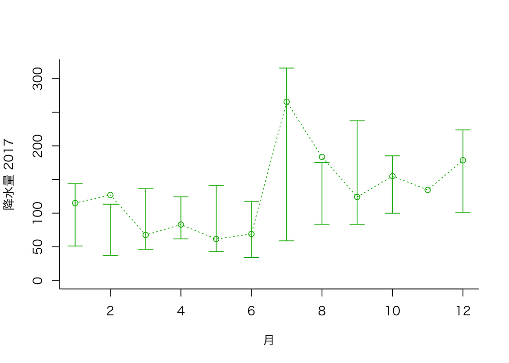

```r
paddingString <- function(numVec) {
  addingMonthNum <- (max(numVec) + 1):12
  # 0 paddingした文字列に変換したvector
  addingMonthString <- sprintf("%02d", addingMonthNum)
  return(addingMonthString)
}

# まだ来てない月の分，項目としては作っておく
notYetMonthVec <- function(yearDF) {
  itemDF <- yearDF[, c("month")]
  # 12月までない場合に，付け足す分のvectorを返す
  if (length(itemDF) < 12) {
    itemDFWithNumMonth <- as.numeric(itemDF)
    notYetMonthStringVec <- paddingString(itemDFWithNumMonth)
    return(notYetMonthStringVec)
  } else {
    return(c())
  }
}

# 特定の項目のデータ
pickData <- function(df, itemName) {
  return(df[, c("month", itemName)])
}

# 付け足す分
addRestMonth <- function(monthDataDF, paddinfStringsVec) {
  for (i in paddinfStringsVec) {
    monthDataDF <- rbind(monthDataDF, c(i, ""))
  }
  return(monthDataDF)
}

plotYear <- function(yearDF, itemName) {
  # その年の，ある項目のデータ
  yearDFForPlotTmp <- pickData(yearDF, itemName)
  # 今年だと，まだ来てない月のデータがない。その分の月を追加してグラフの描画に合わせる
  yearDFForPlot <-
    addRestMonth(yearDFForPlotTmp, notYetMonthVec(yearDF))
  return(yearDFForPlot)
}

# 特定の年のデータ
getYearDF <- function(jmaDF, pickedYear) {
  yearDF <- subset(jmaDF, grepl(pickedYear, format(jmaDF$年月, "%Y")))
  #str(yearDF)
  return(yearDF)
}

getSDBar <- function(jmaDF, itemName) {
  avrByMonth <- tapply(jmaDF[, c(itemName)], jmaDF$month[!is.na(jmaDF$month)], mean)
  sdByMonth <- tapply(jmaDF[, c(itemName)], jmaDF$month[!is.na(jmaDF$month)], sd)
  resultSDVec <- list(avrByMonth, sdByMonth)
  names(resultSDVec) <- c("avr", "sd")
  return(resultSDVec)
}

# プロット用データ データフレーム と年と項目名
plotDotLine <- function(df, year, itemName) {
  # ある年のある項目のデータ
  resultDF <- plotYear(getYearDF(df, year), itemName)
  # その項目の，今までの平均値と標準偏差
  resultSD <- getSDBar(df, itemName)
  # その年の，項目の数字の最大値・最小値(欠損値除く)
  yDataMin <- min(as.numeric(resultDF[, 2]), na.rm = T)
  yDataMax <- max(as.numeric(resultDF[, 2]), na.rm = T)
  # 平均値+標準偏差の最大値
  ySDMin <- min(resultSD$avr - resultSD$sd, na.rm = T)
  # 平均値-標準偏差の最小値
  ySDMax <- max(resultSD$avr + resultSD$sd, na.rm = T)

  # その年のと平均値〜と，どっちか大きい/小さい方(ただし最小値は0含む)
  yMin <- min(yDataMin, ySDMin, 0)
  yMax <- max(yDataMax, ySDMax)
  resultVec <- list(data=resultDF[,2], avr=resultSD$avr, sd=resultSD$sd, ylim=c(yMin, yMax), axtxt=paste(itemName, year))
  return(resultVec)
}

# example 〜〜年の「〜〜」のデータと，今までの標準偏差プロット
# まずデータフレーム と年と項目名
pldata <- plotDotLine(dfList10[["飛島"]], "2017", "降水量")
ydata <- pldata$data
allAvr <- pldata$avr
allSD <- pldata$sd
allylim <- pldata$ylim
axtxt <- pldata$axtxt

par(family = "HiraKakuPro-W3", lty = 3, bty = "l")
plot(
  ydata,
  type = "o",
  ylim = allylim,
  col = rgb(0, 0.7, 0),
  pch = 1,
  xlab = "月",
  ylab = axtxt
)
arrows(
  c(1:12),
  allAvr - allSD,
  c(1:12),
  allAvr + allSD,
  code = 3,
  lwd = 1,
  angle = 90,
  length = 0.1,
  ylim = allylim,
  lty = 1,
  col = rgb(0, 0.7, 0)
)
```

飛島の降水量，11月のバーが出てない。

```r
# which( grepl("降水量", colnames(dfList10[["飛島"]])))
subset(dfList10[["飛島"]], grepl("11", dfList10[["飛島"]]$month), which( grepl("降水量", colnames(dfList10[["飛島"]]))) )
```

```
##     降水量 降水量_品質 降水量_均質
## 14   155.0           8           1
## 26   187.5           8           1
## 38   106.0           8           1
## 50   232.5           8           1
## 62   224.5           8           1
## 74   136.5           8           1
## 86   160.0           8           1
## 98    93.5           8           1
## 110  134.5           8           1
## 122     NA           0           1
```

```r
allSD
```

```
##        01        02        03        04        05        06        07
##  46.25581  38.04179  44.97916  31.30051  49.30788  41.45778 128.39137
##        08        09        10        11        12
##  45.80166  76.92861  42.65234        NA  61.52851
```

getSDBar()にも na.rm = TRUE 要るか。

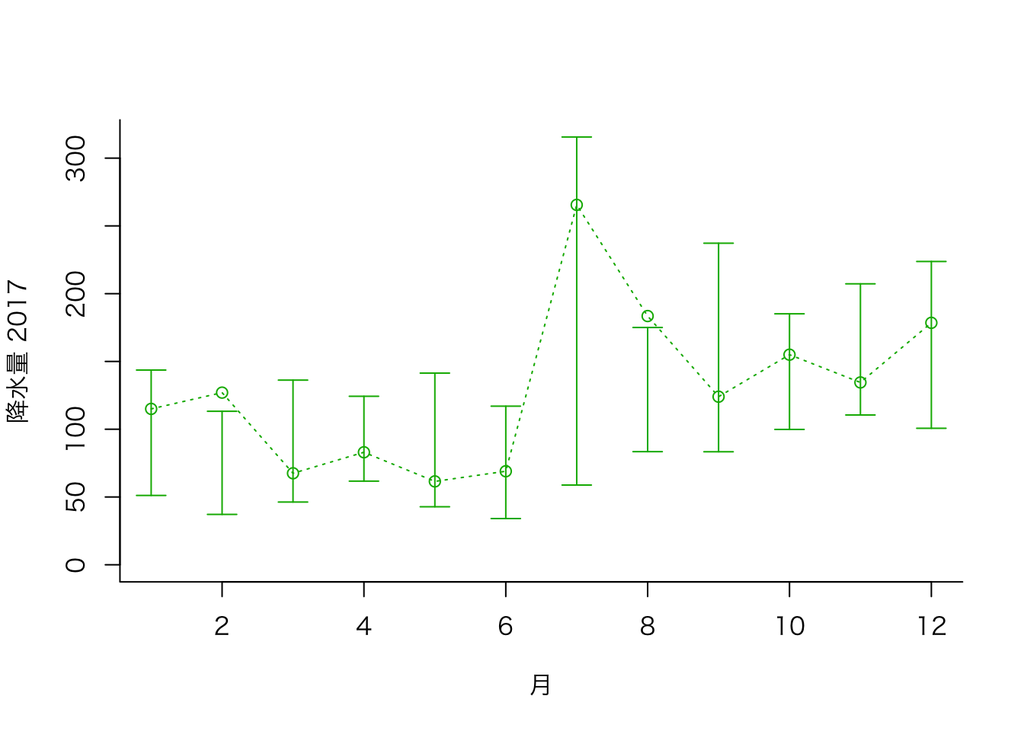

```r
getSDBar <- function(jmaDF, itemName) {
  avrByMonth <- tapply(jmaDF[, c(itemName)], jmaDF$month[!is.na(jmaDF$month)], mean, na.rm=T)
  sdByMonth <- tapply(jmaDF[, c(itemName)], jmaDF$month[!is.na(jmaDF$month)], sd, na.rm=T)
  resultSDVec <- list(avrByMonth, sdByMonth)
  names(resultSDVec) <- c("avr", "sd")
  return(resultSDVec)
}

pldata_1 <- plotDotLine(dfList10[["飛島"]], "2017", "降水量")
ydata_1 <- pldata_1$data
allAvr_1 <- pldata_1$avr
allSD_1 <- pldata_1$sd
allylim_1 <- pldata_1$ylim
axtxt_1 <- pldata_1$axtxt

par(family = "HiraKakuPro-W3", lty = 3, bty = "l")
plot(
  ydata_1,
  type = "o",
  ylim = allylim_1,
  col = rgb(0, 0.7, 0),
  pch = 1,
  xlab = "月",
  ylab = axtxt_1
)
arrows(
  c(1:12),
  allAvr_1 - allSD_1,
  c(1:12),
  allAvr_1 + allSD_1,
  code = 3,
  lwd = 1,
  angle = 90,
  length = 0.1,
  ylim = allylim_1,
  lty = 1,
  col = rgb(0, 0.7, 0)
)
```

試しに散布図

```r
allData <- plotYear(dfList10[["飛島"]], "降水量")
yMax <- max(allData[,2], na.rm=T)

plot(allData, pch=1, xlim=c(1,12), ylim=c(0,yMax), col="#ffffff")
par(new=T)
allData[,1] <- as.numeric(as.character(allData[,1]))
str(allData)
```

```
## 'data.frame':    119 obs. of  2 variables:
##  $ month : num  1 2 3 4 5 6 7 8 9 10 ...
##  $ 降水量: num  153.5 98 88.5 86.5 56.5 ...
```

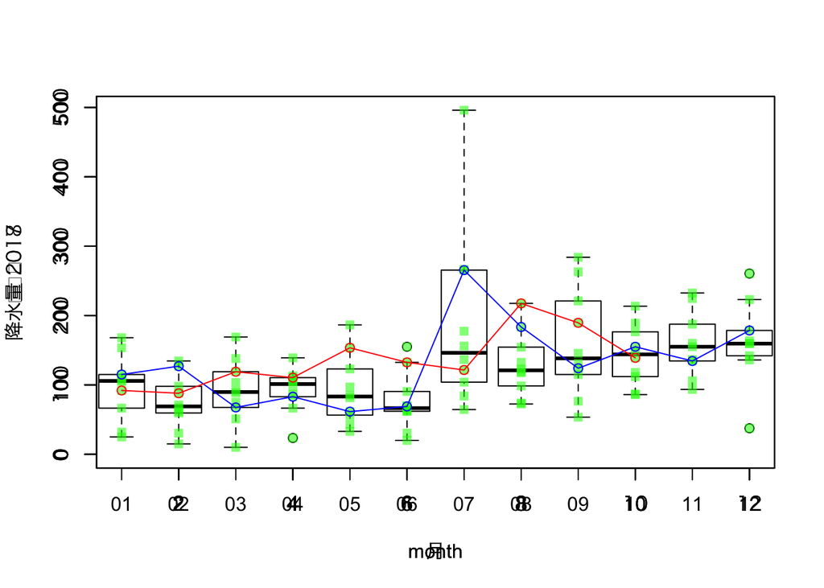

```r
plot(allData, pch=15, xlim=c(1,12), ylim=c(0,yMax), col="#00ff0090")
#
#
pldata_2 <- plotDotLine(dfList10[["飛島"]], "2018", "降水量")
ydata_2 <- pldata_2$data
allAvr_2 <- pldata_2$avr
allSD_2 <- pldata_2$sd
allylim_2 <- pldata_2$ylim
axtxt_2 <- pldata_2$axtxt
par(family = "HiraKakuPro-W3", bty = "l")
par(new=T)
plot(
  ydata_1,
  type = "o",
  ylim = c(0,yMax),
  col = rgb(0, 0, 1),
  pch = 1,
  xlab = "月",
  ylab = axtxt_1
)
par(new=T)
plot(
  ydata_2,
  type = "o",
  ylim = c(0,yMax),
  col = rgb(1, 0, 0),
  pch = 1,
  xlab = "月",
  ylab = axtxt_2
)
```

めんどくさいから，あとで描画用の関数作る。

```r
# jmaPlot <- function(PlotData)
```

あとは

- 全データの散布図
- グラフを楽に書く関数
- for で回さずに mapply使う
- 年月以外，旬，日単位の場合
- 品質が8以外
- 均質が1以外
- 現象なしが0以外

を除去する，